# Creating Cell Cell interaction network

# Cell Cell interactions

Using a set of proteins designated as receptors, and ligands defined with a set of GO terms calculate the set of interactions that represent cell-cell interactions (for example Ligand-receptor, receptor-receptor, …). This analysis is not limited to Cell-Cell interactions. You can define your own protein types, either manually or by choosing different go terms, and create your customized protein-protein interaction network.

Once you have defined the set of protein of interest restrict your dataset to include only proteins found in your protein of interest set. Your dataset can be any type of data. For this example we have downloaded data from GEO representing the expression of different stages of hematopoiesis (originally from [this publication](https://www.ncbi.nlm.nih.gov/pubmed/23708252)).

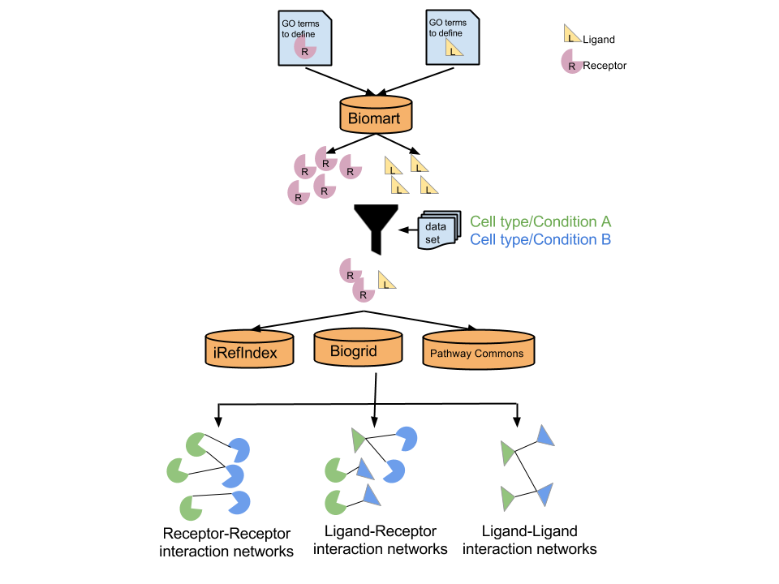

**Data analysis flow chart**

For this analysis the user supplies a dataset (condition A vs condition B or cell type A vs cell type B). One can start with GEO id or alternately supply a scored dataset.

The result of the analysis is a ligand receptor interaction network generated in cytoscape which depicts all interactions. In order for an interaction to be included both proteins do not need to be significant. The rationale is that we want to see the potential interactions. If both members are present it might be sufficient for the interaction to occur. They don’t necessarily need to be differentially expressed in order for the interaction to occur.

There are different configuarble parameters that the users can tweak listed below:

## configurable parameters

User configurable Parameters:

- celltype_column - the name of the column in the table that specifies which cell type the gene is associate with.
- genename_column - The name of the column in the dataset table that contains the gene symbol. This is dependant on where the data is coming from. Using GEO2R to convert probe ids to gene names use this column name
- FC_thresh - Foldchange threshold - How differential does the gene need to be in order to classify it as cell type A or cell type B
- significance_filter - TRUE/FALSE, set filter to true if you would like to filter the dataset by p-value and fdr thresholds. Even if you choose not to filter the dataset keep these thresholds at desired numbers as in the resulting network any gene that passes these thresholds will be highlighted as a significant gene.
- fdr_thresh - false discovery threhold - (optional) used to filter the dataset.
- pval_thresh - p-value threshold - (optional) used to filter the dataset
- cell_typeA - name of cell type A
- cell_typeB - name of cell type B
- collection - name of resulting cytoscape network collection
- name - name of resulting cytoscape network
- style_name - name of cytoscape style

```r
#The name of the column in the table that specifies which cell type the gene is associate with.
celltype_column <- "Type"
#The name of the column in the table that contains the gene symbol
#This is dependant on where the data is coming from.  Using GEO2R to convert probe ids to gene names use this column name
genename_column <- "Symbol"

#Foldchange threshold - How differential does the gene need to be in order to classify it as cell type A or cell type B
FC_thresh <- 1

#set filter to true if you would like to filter the dataset by p-value and fdr thresholds
# Even if you choose not to filter the dataset keep these thresholds at desired numbers as in the resulting network any gene that
# passes these thresholds will be highlighted as a significant gene.
significance_filter <- FALSE
#False discovery threhold - (optional) used to filter the dataset.
fdr_thresh <- 1
#p-value threshold - (optional) used to filter the dataset
pval_thresh <- 0.05

#name of resulting cytoscape network collection
collection = paste("ligand_receptor_network",FC_thresh,sep="_") # name of cytoscape collection

#definition of cell types - can be any number of cell-types.
cell_typeA <- "celltypeA"
cell_typeB <- "celltypeB"
celltype_names <- c(cell_typeA,cell_typeB)

#name of resulting cytoscape network
name = paste(cell_typeA,cell_typeB,"interactions","pval",pval_thresh, "fdr",fdr_thresh,"FC",FC_thresh,sep="_") #network name

#name of cytoscape style
style_name <- "cellcell_style"

# flag whether to compute iref complex interactions
compute_iref_complexes <- FALSE

source ("./R_code/CellCellInteractions_utility_functions.R")
```

## Define the ligands and receptors

Receptors are defined as any gene annotated to the following GO terms:

- GO CC - GO:0043235 - receptor complex, GO:0008305 - integrin complex
- GO BP - GO:0072657 - protein localized to membrane, GO:0043113 - receptor clustering
- GO MF - GO:0004872 -receptor activity

Ligands are defined as any gene annotated to the following GO terms:

- GO MF - GO:0005102 - receptor binding

To modify or customize what is defined as a receptor or ligand add/delete any of the GO terms below.

```r
#make sure you have biomart package installed - uncomment below if it is not installed
 #source("http://bioconductor.org/biocLite.R")
#  biocLite("biomaRt")
goterms_receptors <- c("GO:0043235","GO:0008305","GO:0072657","GO:0043113","GO:0004872")
goterms_ligands <- c("GO:0005102")
```

```r
  library("biomaRt")
  ensembl=useMart("ensembl",dataset="hsapiens_gene_ensembl")

  #filter for the set of goterms
  attribs = c('entrezgene','hgnc_symbol','go_id','name_1006','go_linkage_type','namespace_1003');

  genes_recep <- getBM(attributes = attribs,filters = 'go_parent_term', values = goterms_receptors, mart = ensembl)
  genes_ligand <- getBM(attributes = attribs,filters = 'go_parent_term', values = goterms_ligands, mart = ensembl)
```

## Number of Receptors and Ligands

Biomart returned 2158 unique genes annotated to the one of the Receptor go term queries GO:0043235, GO:0008305, GO:0072657, GO:0043113, GO:0004872 or one their 446 child terms.

Go terms are assigned with different [evidence codes](http://www.geneontology.org/page/guide-go-evidence-codes). We can use these codes to help refine our subset of genes. for example, If we want to restrict our set of genes to a higher confidence set we can exclude any annotaions that are “inferred from electronic annoations”.

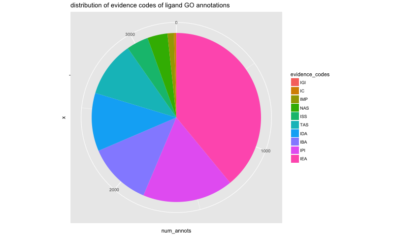

**Evidence codes - Ligands**

```r
library(ggplot2)
evidence_code_dist_ligands <- aggregate(genes_ligand$go_linkage_type, by=list(genes_ligand$go_linkage_type), FUN=length)
colnames(evidence_code_dist_ligands) <- c("evidence_code","num_annotations")

evidence_code_dist_ligands <- evidence_code_dist_ligands[order(evidence_code_dist_ligands[,2]),]

evidence_codes <- factor(evidence_code_dist_ligands[,"evidence_code"], levels = evidence_code_dist_ligands[,"evidence_code"])
num_annots <- evidence_code_dist_ligands[,"num_annotations"]

figures_directory <- paste(getwd(),"Figures",sep="/")
dir.create(figures_directory ,showWarnings = FALSE)

evidence_codes_ligands_file <- paste(figures_directory,"evidence_codes_ligands.png", sep="/")
png(evidence_codes_ligands_file,width = 800)

ggplot(evidence_code_dist_ligands, aes(x="", y=num_annots, fill=evidence_codes)) + geom_bar(width = 1, stat = "identity") + coord_polar("y", start=0) + ggtitle("distribution of evidence codes of ligand GO annotations")

dev.off()
```

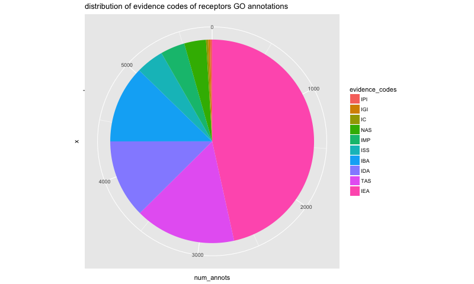

**Evidence codes - Receptors**

```r
evidence_code_dist_receptors <- aggregate(genes_recep$go_linkage_type, by=list(genes_recep$go_linkage_type), FUN=length)
colnames(evidence_code_dist_receptors) <- c("evidence_code","num_annotations")

evidence_code_dist_receptors <- evidence_code_dist_receptors[order(evidence_code_dist_receptors[,2]),]

evidence_codes <- factor(evidence_code_dist_receptors[,"evidence_code"], levels = evidence_code_dist_receptors[,"evidence_code"])
num_annots <- evidence_code_dist_receptors[,"num_annotations"]

evidence_codes_receptors_file <- paste(figures_directory,"evidence_Codes_receptors.png", sep="/")
png(evidence_codes_receptors_file,width = 800)
  ggplot(evidence_code_dist_receptors, aes(x="", y=num_annots, fill=evidence_codes)) + geom_bar(width = 1, stat = "identity") + coord_polar("y", start=0) + ggtitle("distribution of evidence codes of receptors GO annotations")

dev.off()
```

Given the large set of genes returned for the specified GO terms plus the large percentage of annotations that have “inferred from electronic annotation” evidence code we can narrow the set by excluding those annotations.

```r
genes_recep_filtered <- data.frame(genes_recep[which(genes_recep$go_linkage_type != "IEA"),], protein_type = "Receptor")
genes_ligand_filtered <- data.frame(genes_ligand[which(genes_ligand$go_linkage_type != "IEA"),],protein_type = "Ligand")
all_types <- rbind(genes_recep_filtered, genes_ligand_filtered)
func_paste <- function(x) paste(unique(x), collapse = ',')
protein_types_attribs <- aggregate(all_types, by=list(all_types[,"hgnc_symbol"]), func_paste)[,2:8]
```

```r
#This is the set of genes/proteins we are going to filter our interaction by.  If you have your own set of genes/proteins of interest you can definge them here and skip the GO calculation.
#prteins_of_interest is a vector of gene symobls
proteins_of_interest <- unique(c(genes_recep_filtered[,2],genes_ligand_filtered[,2]))
```

This results in: * 1865 unique genes classified as receptors * 1190 unique genes classified as ligands * There are 221 genes that are classified as both receptors and ligands

prior to filtering to exclude IEA annotations there were: * 2158 unique genes classified as receptors * 1481 unique genes classified as ligands * There are 325 genes that are classified as both receptors and ligands

## Sources of interactions:

1. [IRefIndex](http://irefindex.org/wiki/index.php?title=README_MITAB2.6_for_iRefIndex) - Originally, interactions were obtained from IRefIndex. Irefindex was last updated in April 2015 but when we tried to use it the latest release had less interactions than the previous version so we kept using the older version which is from August 2013.
2. [Biogrid](https://thebiogrid.org/download.php) - an updated resource but it doesn’t include all database like irefindex.
- To get the latest version of biogrid use latest version links (for example https://thebiogrid.org/downloads/archives/Latest%20Release/BIOGRID-ALL-LATEST.mitab.zip). It is different depending on the type of file you want to download.
1. [Pathway Commons](http://www.pathwaycommons.org) - although pathway commons is primarily a pathway database there are a lot of interactions that make up pathways. Pahtway commons currently (April 2016) collates data from 22 data sources and has a restful API. For the purpose of this analysis we are going to download the entire set of interactions in sif format that is available on there download site as opposed to using their restul-API. Rest is good for accessing small to medium amounts of data but given we want the entire set it is more effecient to use the bulk download.

### Biogrid

Interactions in mitab format are translated into genesymbol - genesymbol interactions. Each database uses their own base identifiers but users most often look at their results on the gene symbol level. The base identifier for Biogrid is entrez gene id and gene symbols are placed in alternate id columns.

```r
inter_directory = "InteractionSrc_files"
src_directory = "Biogrid"
biogrid_dir = paste(getwd(),inter_directory,src_directory,sep="/")
dir.create(paste(getwd(),inter_directory,sep="/"), showWarnings = FALSE)
dir.create(biogrid_dir, showWarnings = FALSE)

biogrid_url = "https://thebiogrid.org/downloads/archives/Latest%20Release/BIOGRID-ORGANISM-LATEST.mitab.zip"
biogrid_interaction_zipfile = paste(biogrid_dir ,"/biogrid_",format(Sys.time(), "%b_%d_%Y"),".mitab.zip",sep="")
biogrid_interaction_file = paste(biogrid_dir ,"//biogrid_",format(Sys.time(), "%b_%d_%Y"),".mitab",sep="")

## download the latest version of biogrid.
download.file(
    biogrid_url,
    destfile=biogrid_interaction_zipfile
)
```

```r
#unzip the new file
files_in_zip = unzip(biogrid_interaction_zipfile,exdir=inter_directory, list=TRUE)
human_file = files_in_zip[grep(files_in_zip[,1], pattern="Homo_sapiens"),1]
unzip(biogrid_interaction_zipfile,exdir=inter_directory, files=human_file)

#load in the mitab file
biogrid_mitab = read.delim(paste(inter_directory,"/",human_file,sep=""), as.is=T, check.names=F, na.strings=c(NA,""))
```

Biogrid contains 334979 records.

The distribution of the different types of interactions:

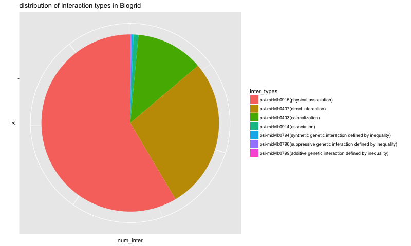

**Biogrid - interaction types**

```r
intertypes_dist_biogrid <- aggregate(biogrid_mitab$`Interaction Types`, by=list(biogrid_mitab$`Interaction Types`), FUN=length)
colnames(intertypes_dist_biogrid) <- c("Interaction Type","num_interactions")

intertypes_dist_biogrid<- intertypes_dist_biogrid[order(intertypes_dist_biogrid[,2],decreasing = TRUE),]

inter_types <- factor(intertypes_dist_biogrid[,"Interaction Type"], levels = intertypes_dist_biogrid[,"Interaction Type"])
num_inter <- intertypes_dist_biogrid[,"num_interactions"]

biogrid_intertype_file <- paste(figures_directory,"biogrid_intertypes.png", sep="/")
png(biogrid_intertype_file,width = 800)

ggplot(intertypes_dist_biogrid, aes(x="", y=num_inter, fill=inter_types)) + geom_bar(width = 1, stat = "identity") + coord_polar("y", start=0) + ggtitle("distribution of interaction types in Biogrid") +  theme(axis.text = element_blank())

dev.off()
```

Filter biogrid by the set of ligands and receptors. For an interaction to be retained in the final set both protein A and protein B must be in our proteins of interest set. We are looking for interactions between Receptors and ligands (or ligands and ligands, or receptors and receptors)

Gene symbols are found in the alternate id column (column 3 and 4 in the biogrid mitab file)

```r
biogrid_ligand_recep_inter <- filter_mitab_interactions_byproteinset(biogrid_mitab,proteins_of_interest,
                                                                     pattern="entrez gene/locuslink:",
                                                                    column_alias1=3,column_alias2=4)
```

After filtering biogrid by our set of proteins of interest there are 23766 records where protein A and protein B are in our set of protein of interest.

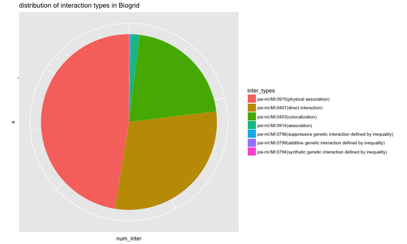

**Biogrid - interaction types [Filtered]**

```r
intertypes_dist_biogrid <- aggregate(biogrid_ligand_recep_inter$`Interaction Types`, by=list(biogrid_ligand_recep_inter$`Interaction Types`), FUN=length)
colnames(intertypes_dist_biogrid) <- c("Interaction Type","num_interactions")

intertypes_dist_biogrid<- intertypes_dist_biogrid[order(intertypes_dist_biogrid[,2],decreasing = TRUE),]

inter_types <- factor(intertypes_dist_biogrid[,"Interaction Type"], levels = intertypes_dist_biogrid[,"Interaction Type"])
num_inter <- intertypes_dist_biogrid[,"num_interactions"]

biogrid_intertype_file_filtered <- paste(figures_directory,"biogrid_intertypes_filtered.png", sep="/")
png(biogrid_intertype_file_filtered,width = 800)

ggplot(intertypes_dist_biogrid, aes(x="", y=num_inter, fill=inter_types)) + geom_bar(width = 1, stat = "identity") + coord_polar("y", start=0) + ggtitle("distribution of interaction types in Biogrid") +  theme(axis.text = element_blank())

dev.off()
```

```r
#compute the unique number of interactions
keys_biogrid<- unique(paste(biogrid_ligand_recep_inter[,1],biogrid_ligand_recep_inter[,2],sep="") )
```

In order to decrease some of the redundancy in the interaction set from each interaction create a key consisting of proteinA and protein B. (key = genenameA_genenameB) With the key we can collapse interactions that are identified in multiple publications or by multiple methods. If the same interaction is described in the database as protein B interacts with protein A it would be retained as a different interaction as this basic method doesn’t account for that. This can be handled in the results PPI network that we generate in cytoscape as we can remove duplicated edges.

There are 15669 unique interactions with our proteins of interest in the biogrid set.

### Pathway commons

```r
#only get the file that contains all sources
rx = gregexpr("(?<=<a href=\")(PathwayCommons.*.All.EXTENDED_BINARY_SIF.hgnc)(.txt.gz)(?=\">)",
  contents, perl = TRUE)
pc_file = unlist(regmatches(contents, rx))
pc_interaction_zipfile <- pc_file
dest_pc_interaction_zipfile <- paste(pc_dir,pc_interaction_zipfile,sep="/")

download.file(
    paste(pc_url,pc_interaction_zipfile,sep="/"),
    destfile=dest_pc_interaction_zipfile
)
```

```r
pc_interaction_file = gsub(pattern = ".gz",replacement = "",pc_interaction_zipfile)
if (file.exists(paste(pc_dir,pc_interaction_file,sep="/"))) {
  response = file.remove(paste(pc_dir,pc_interaction_file,sep="/"))
  }

gunzip(paste(pc_dir,pc_interaction_zipfile,sep="/"))

#load in the extended binary sif file (there are actually two files contained in this individual file)
pc_data = read.delim(paste(pc_dir,"/",pc_interaction_file,sep=""), as.is=T, check.names=F, na.strings=c(NA,""))

pc_protein_data_colnames <- pc_data[which(pc_data[,1]=="PARTICIPANT"),which(!is.na(pc_data[which(pc_data[,1]=="PARTICIPANT"),]))]
pc_protein_data <- pc_data[(which(pc_data[,1]=="PARTICIPANT")+1):dim(pc_data)[1],1:length(which(!is.na(pc_data[which(pc_data[,1]=="PARTICIPANT"),])))]
colnames(pc_protein_data) <- pc_protein_data_colnames

pc_data <- pc_data[1:(which(pc_data[,1]=="PARTICIPANT")-1),]
```

```r
protein_set <- proteins_of_interest
AliasA <- pc_data[,1]
AliasB <- pc_data[,3]
pc_RL_interaction_set <- pc_data[which(AliasA %in% protein_set & AliasB %in% protein_set),]
num_pc2_inter <- dim(pc_RL_interaction_set)[1]

#compute the unique number of interactions
keys_pc2<- paste(pc_RL_interaction_set[,1],pc_RL_interaction_set[,3],sep="")
num_pc2_uniq_interactions <- length(unique(keys_pc2))
```

There are a total of 67812 interactions in the pathway commons set (55918 unique interactions).

### IRefindex

```r
inter_directory = "InteractionSrc_files"
src_directory = "irefindex"
iref_dir = paste(getwd(),inter_directory,src_directory,sep="/")
dir.create(paste(getwd(),inter_directory,sep="/"), showWarnings = FALSE)
dir.create(iref_dir, showWarnings = FALSE)

iref_url <- "http://irefindex.org/download/irefindex/data/archive/release_13.0/psi_mitab/MITAB2.6/9606.mitab.08122013.txt.zip"

iref_interaction_zipfile = paste(iref_dir, "9606.mitab.08122013.txt.zip",sep="/")
iref_interaction_file = paste(iref_dir, "9606.mitab.08122013.txt",sep="/")

## download the latest version of biogrid.
download.file(
    iref_url,
    destfile=iref_interaction_zipfile
)
```

```r
unzip(iref_interaction_zipfile,exdir=iref_dir )

iref_2013 = read.delim(iref_interaction_file,
                       as.is=T, check.names=F, na.strings=c(NA,""))

dim(iref_2013)
```

```
## [1] 687515     54
```

#### Remove biogrid from the iref set because we are getting them from the source

Biogrid and Iref represent complexes very differently. Instead of taking the iref interpretation of the interaction take it directly from the source. Remove all interaction from Iref set that have sourcedb == “MI:0463(biogrid)”

```r
num_to_remove <- dim(iref_2013[which(iref_2013[,"sourcedb"] == "MI:0463(biogrid)"),])[1]
paste("Removed ",num_to_remove ,
      "interactions from iref set.  (interactions in iref that are from biogrid)")
```

```
## [1] "Removed  215050 interactions from iref set.  (interactions in iref that are from biogrid)"
```

```r
iref_2013_nobiogrid <- iref_2013[which(iref_2013[,"sourcedb"] != "MI:0463(biogrid)"),]
```

#### Compute Receptor - ligand interactions

```r
iref_ligand_recep_inter <- filter_mitab_interactions_byproteinset(
                                iref_2013_nobiogrid,proteins_of_interest,
                                pattern="hgnc:",
                                column_alias1=5,column_alias2=6)
```

#### Compute interactions from IRef complex interaction representation and filter by receptor ligand interactions

translate mitab irefIndex complex records into pair-wise interactions. Complexes are stored in iref as a set of interactions where each pairwise interaction is between one member of the complex and the complex record itself. **This step takes quite a bit of time.**

By default we don’t compute this.

```r
#this method converts the complexes into a matrix representation.
if(compute_iref_complexes){
  iref_ligand_recep_complexes <- compute_complex_interactions_irefindex(
    iref_2013_nobiogrid,proteins_of_interest)
}
```

#### Create the final set of receptor ligand interactions from interaction and complexes set

```r
num_iref_complex_inter <- 0

#get rid of any interactions that have one molecule specified as NA
  iref_ligand_recep_inter <- iref_ligand_recep_inter[which(!is.na(iref_ligand_recep_inter[,2]) & !is.na(iref_ligand_recep_inter[,1]) ),]
  num_iref_inter <- dim(iref_ligand_recep_inter)[1]

#get rid of any interactions that have one molecule specified as NA
if(compute_iref_complexes){
  iref_ligand_recep_complexes <- iref_ligand_recep_complexes[which(!is.na(iref_ligand_recep_complexes[,2]) & !is.na(iref_ligand_recep_complexes[,1]) ),]
  num_iref_complex_inter <- dim(iref_ligand_recep_complexes)[1]

  iref_ligand_recep_inter_all <- rbind(iref_ligand_recep_inter, iref_ligand_recep_complexes)
} else{

  iref_ligand_recep_inter_all <- iref_ligand_recep_inter
}


num_iref_inter_all <- dim(iref_ligand_recep_inter_all)[1]

#compute the unique number of interactions
keys_iref_2013 <- unique(paste(iref_ligand_recep_inter_all[,1],iref_ligand_recep_inter_all[,2],sep="") )
```

Iref consists of 41194 ligand-receptor interactions, 0 from complexes and 41194 from interaction records. Of the 41194 there are 9828 “unique interactions” (unique interactions is in quotes as it is not strictly unique. We have not excluded interactions that have records specifying the interaction of A-B and another record that specifies the interaction B-A)

## Merge the three different interaction sources

### How many interactions do they have in common

```r
library(VennDiagram)
```

```r
three_db_overlap = paste(".","3_db_RL_inter_overlap.png",sep="/")
png(three_db_overlap)

draw.triple.venn(area1 = length(keys_iref_2013),
                 area2 = length(keys_biogrid),
                 area3 = length(keys_pc2),
                 n12 = length(intersect(keys_iref_2013,keys_biogrid)),
                 n23 = length(intersect(keys_biogrid, keys_pc2)),
                 n13 = length(intersect(keys_iref_2013,keys_pc2)),
                 n123 = length(intersect(keys_iref_2013, intersect(keys_biogrid, keys_pc2 ))),
                 category = c("iref_2013\n (no biogrid)", "biogrid", "pc2"), lty = "blank",
    fill = c("skyblue", "pink1", "mediumorchid"))
```

[output not shown]

```r
dev.off()
```

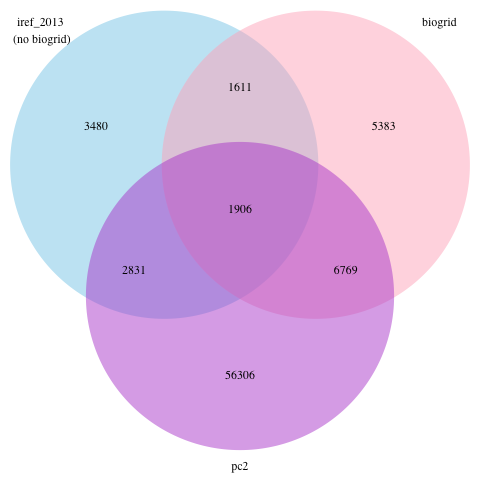

Figure:Overlap of 3 different db (iref, biogrid, pc2) receptor ligand sets

The above venn diagram shows that although iref has a lot of interactions there are significantly more interactions that we can get from the pathway interaction databases in pathway commons.

## Output the final interaction file to be used by other notebooks and processes.

Both iref and biogrid were downloaded in mitab so the interaction structures is very similiar. Unfortunately pathway commons data is not available in mitab format so we downloaded the data in sif file which has comparable data but it is not the exact same as the mitab.

The mitab file contains:

- **uidA** - main identifier of protein A
- **uidB** - main identifier of protein B
- **altA** - list of the alternate identifiers for protein A
- **altB** - list of the alternate identifiers for protein B
- **aliasA** - list of alternate aliases for protein A
- **aliasB** - list of alternate aliases for protein B
- **method** - psimi controlled vocabulary term indicating the method the interaction was discovered using (for example (-,MI:0492(in vitro),MI:0018(two hybrid),MI:0007(anti tag coimmunoprecipitation),MI:0030(cross-linking study),MI:0676(tandem affinity purification),MI:0019(coimmunoprecipitation),MI:0064(interologs mapping),MI:0096(pull down),MI:0114(x-ray crystallography)))
- **author**
- **pmids** - list of pmids this interaction is associated with
- **taxa** - taxonomy of protein A
- **taxb** - taxonomy of protein B
- **interactionType** - for mitab file this is psimi controlled vocabulary term indicating the interactions type (one of, for example, [psi-mi:MI:0407(direct interaction),psi-mi:MI:0915(physical association),psi-mi:MI:0796(suppressive genetic interaction defined by inequality),psi-mi:MI:0914(association),psi-mi:MI:0403(colocalization),psi-mi:MI:0799(additive genetic interaction defined by inequality),psi-mi:MI:0794(synthetic genetic interaction defined by inequality)] for biogrid data and one of, for example, [-,MI:0914(association),MI:0191(aggregation),MI:0407(direct interaction),MI:0915(physical association),MI:0194(cleavage reaction),MI:0403(colocalization),MI:0000(psi-mi:MI:0915),MI:0557(adp ribosylation reaction),MI:0217(phosphorylation reaction)] for iref data.
- **sourcedb** - source database of interaction (iref has a large collection of interactions so although the interaction might be downloaded from iref this column will specify the source database)
- **interactionIdentifier** - the identifier in the source database
- **confidence** - calculated metric indicating the confidence of the interaction (each database or interaction detection method might have a different scale and system.)

we added two columns to the front of the above format:

- **AliasA** - gene symbol extracted from the list of aliases for protein A
- **AliasB** - gene symbol extracted from the list of aliases for protein B

The binary sif file (supplied by pathway commons) contains:

- **PARTICIPANT_A** - gene symbol of protein A
- **INTERACTION_TYPE** - interaction type (one of: controls-state-change-of, controls-transport-of,controls-phosphorylation-of, controls-expression-of,catalysis-precedes, in-complex-with, interact-with, neighbor-of,consumption-controled-by, controls-production-of, controls-transport-of-chemical, chemical-affects, reacts-with, used-to-produce)
- **PARTICIPANT_B** - gene symbol of protein B
- **INTERACTION_DATA_SOURCE** - source of intearction
- **INTERACTION_PUBMED_ID** - publications associated with interaction
- **PATHWAY_NAMES** - names of pathways the interaction is associated with.
- **MEDIATOR_IDS** -

There is also additional information in extended sif file that we could add:

- **PARTICIPANT** - same as participant A / B above
- **PARTICIPANT_TYPE**
- **PARTICIPANT_NAME**
- **UNIFICATION_XREF**
- **RELATIONSHIP_XREF**

## Merge biogrid and iref

Given that they are in the same format it is straight forward to merge the two sets. The only difference between them is that iref has more information than biogrid but the first 15 columns are exactly the same.

```r
ligandrecep_dir <- paste(getwd(),inter_directory,"./Ligand_Receptor_InteractionSets/",sep="/")
dir.create(ligandrecep_dir, showWarnings = FALSE)
base_name  <- "LigandReceptorInteractions"

#give biogrid the same column names as Iref
colnames(biogrid_ligand_recep_inter) <- colnames(iref_ligand_recep_inter_all)[1:dim(biogrid_ligand_recep_inter)[2]]

#only grab the first set of columns from iref as they have a lot more info
complete_interaction_set <- rbind(
                    iref_ligand_recep_inter_all[,1:dim(biogrid_ligand_recep_inter)[2]],
                     biogrid_ligand_recep_inter)

key <- do.call(paste, c(complete_interaction_set[c('AliasA','AliasB')],sep="_") )
complete_interaction_set_withkey <- cbind(key,complete_interaction_set)
```

## Add the pathway commons data

Because the pathway commons data is not in the same format as iref and biogrid we will have to create empty columns

```r
#add the protein information for participant A
added_protA <- merge(pc_RL_interaction_set,pc_protein_data,by.x=1,by.y=1,all.x = TRUE)
colnames(added_protA)[(dim(pc_RL_interaction_set)[2]+1):dim(added_protA)[2]] <- paste( colnames(added_protA)[(dim(pc_RL_interaction_set)[2]+1):dim(added_protA)[2]], "A",sep="_")

#add the protein information for participant A
added_protB <- merge(added_protA,pc_protein_data,by.x=1,by.y=1,all.x = TRUE)
colnames(added_protB)[(dim(added_protA)[2]+1):dim(added_protB)[2]] <- paste( colnames(added_protB)[(dim(added_protA)[2]+1):dim(added_protB)[2]], "B",sep="_")

pc_RL_interaction_set_annot <- added_protB

pc_fake_mitab_ligand_receptor_inter <- data.frame(AliasA = pc_RL_interaction_set_annot["PARTICIPANT_A"],
                                                  AliasB = pc_RL_interaction_set_annot["PARTICIPANT_B"],
                                                  uidA = pc_RL_interaction_set_annot["UNIFICATION_XREF_A"],
                                                  uidb = pc_RL_interaction_set_annot["UNIFICATION_XREF_B"],
                                                  alta = "", altb="",
                                                  aliasA = "", aliasB = "", method ="", author = "",
                                                  pmids =  pc_RL_interaction_set_annot["INTERACTION_PUBMED_ID"],
                                                  taxa = "",
                                                  taxb = "",
                                                  ineractionType = pc_RL_interaction_set_annot["INTERACTION_TYPE"],
                                                  sourcedb = pc_RL_interaction_set_annot["INTERACTION_DATA_SOURCE"],
                                                  interactionIdentifier = pc_RL_interaction_set_annot["PATHWAY_NAMES"],
                                                  confidence = ""
                                                  )


#give biogrid the same column names as Iref
colnames(pc_fake_mitab_ligand_receptor_inter) <- colnames(iref_ligand_recep_inter_all)[1:dim(pc_fake_mitab_ligand_receptor_inter)[2]]

key <- do.call(paste, c(pc_fake_mitab_ligand_receptor_inter[c('AliasA','AliasB')],sep="_") )
pc_fake_mitab_ligand_receptor_inter_withkey <- cbind(key,pc_fake_mitab_ligand_receptor_inter)

#only grab the first set of columns from iref as they have a lot more info
complete_interaction_set_withkey <- rbind(
                    complete_interaction_set_withkey,
                     pc_fake_mitab_ligand_receptor_inter_withkey)

interaction_set <- complete_interaction_set_withkey

##add a version of the file that has the date that it was created
write.table(complete_interaction_set_withkey,
            paste(ligandrecep_dir, base_name,"withkeys",format(Sys.time(), "%b_%d_%Y"),
                  ".txt", sep=""),
            col.name=TRUE,sep="\t",
            row.names=FALSE,quote=FALSE)
```

# Load dataset

** Periodically the script doesn’t successfully download the required files from GEO. If this occurs just re-run this section. It rarely fails on consecutive tries **

```r
################################################################
#   Differential expression analysis with limma

# load series and platform data from GEO

gset <- getGEO("GSE42414", GSEMatrix =TRUE, AnnotGPL=FALSE)
```

```
## https://ftp.ncbi.nlm.nih.gov/geo/series/GSE42nnn/GSE42414/matrix/
```

```
## OK
```

```
## Found 1 file(s)
```

```
## GSE42414_series_matrix.txt.gz
```

```
## File stored at:
```

```
## /var/folders/rs/hvp4fcd13vjc95f750sqzs3c0000gp/T//Rtmpb707pD/GPL14951.soft
```

```r
if (length(gset) > 1) idx <- grep("featureNames(gse)[1:10]", attr(gset, "names")) else idx <- 1
gset <- gset[[idx]]

# make proper column names to match toptable
fvarLabels(gset) <- make.names(fvarLabels(gset))

# group names for all samples
gsms <- "000000000011111XXXXXXXXXXXXXXXXXXXXXXXXXX"
sml <- c()
for (i in 1:nchar(gsms)) { sml[i] <- substr(gsms,i,i) }

# eliminate samples marked as "X"
sel <- which(sml != "X")
sml <- sml[sel]
gset <- gset[ ,sel]

# log2 transform
ex <- exprs(gset)
qx <- as.numeric(quantile(ex, c(0., 0.25, 0.5, 0.75, 0.99, 1.0), na.rm=T))
LogC <- (qx[5] > 100) ||
          (qx[6]-qx[1] > 50 && qx[2] > 0) ||
          (qx[2] > 0 && qx[2] < 1 && qx[4] > 1 && qx[4] < 2)
if (LogC) { ex[which(ex <= 0)] <- NaN
  exprs(gset) <- log2(ex) }

# set up the data and proceed with analysis
sml <- paste("G", sml, sep="")    # set group names
fl <- as.factor(sml)
gset$description <- fl
design <- model.matrix(~ description + 0, gset)
colnames(design) <- levels(fl)
fit <- lmFit(gset, design)
cont.matrix <- makeContrasts(G1-G0, levels=design)
fit2 <- contrasts.fit(fit, cont.matrix)
fit2 <- eBayes(fit2, 0.01)
tT <- topTable(fit2, adjust="fdr", sort.by="B",n=Inf)

tT <- subset(tT, select=c("ID","adj.P.Val","P.Value","t","B","logFC","GI","SEQUENCE","GB_ACC"))
#write.table(tT, file=stdout(), row.names=F, sep="\t")


################################################################
#   Boxplot for selected GEO samples

# load series and platform data from GEO

gset <- getGEO("GSE42414", GSEMatrix =TRUE, getGPL=FALSE)
```

```
## https://ftp.ncbi.nlm.nih.gov/geo/series/GSE42nnn/GSE42414/matrix/
```

```
## OK
```

```
## Found 1 file(s)
```

```
## GSE42414_series_matrix.txt.gz
```

```
## Using locally cached version: /var/folders/rs/hvp4fcd13vjc95f750sqzs3c0000gp/T//Rtmpb707pD/GSE42414_series_matrix.txt.gz
```

```r
if (length(gset) > 1) idx <- grep("GPL14951", attr(gset, "names")) else idx <- 1
gset <- gset[[idx]]

# group names for all samples in a series
gsms <- "000000000011111XXXXXXXXXXXXXXXXXXXXXXXXXX"
sml <- c()
for (i in 1:nchar(gsms)) { sml[i] <- substr(gsms,i,i) }
sml <- paste("G", sml, sep="")  #set group names

# eliminate samples marked as "X"
sel <- which(sml != "GX")
sml <- sml[sel]
gset <- gset[ ,sel]

# order samples by group
ex <- exprs(gset)[ , order(sml)]
sml <- sml[order(sml)]
fl <- as.factor(sml)
labels <- c("group1","group2")

# set parameters and draw the plot
palette(c("#dfeaf4","#f4dfdf", "#AABBCC"))
dev.new(width=4+dim(gset)[[2]]/5, height=6)
par(mar=c(2+round(max(nchar(sampleNames(gset)))/2),4,2,1))
title <- paste ("GSE42414", '/', annotation(gset), " selected samples", sep ='')
boxplot(ex, boxwex=0.6, notch=T, main=title, outline=FALSE, las=2, col=fl)
legend("topleft", labels, fill=palette(), bty="n")
```

[output not shown]

Add gene names to the scored GEO data.

```r
#add gene symbols to the expression values
chip_annotation_type  <- annotation(gset)

platf <- getGEO(chip_annotation_type , AnnotGPL=TRUE)
```

```
## Annotation GPL not available, so will use submitter GPL instead
```

```
## Using locally cached version of GPL14951 found here:
## /var/folders/rs/hvp4fcd13vjc95f750sqzs3c0000gp/T//Rtmpb707pD/GPL14951.soft
```

```r
IDs2genesymbol <- attr(dataTable(platf), "table")[,c("ID","Symbol")]
```

```r
scored_data <- merge(IDs2genesymbol, tT, by.x = 1,by.y = 1, all.y = TRUE)
scored_data <- scored_data[order(scored_data$t,decreasing = TRUE),]
```

We now have a scored data set that represents the differential expression between two different cell types. There are different ways we can define which genes are which cell type.

Data has duplicate gene symbols as it is probe level data

```r
#order the data by symbol and pvalue making sure the lowest p-value is the first occurence for a given gene
scored_data<- scored_data[order(scored_data[,genename_column], scored_data$P.Value,decreasing = FALSE),]

#get rid of duplicates
data <- scored_data[!duplicated(scored_data[,genename_column]),]
```

## Calculate the cell types

In this analysis the expression of a set of genes between two cell types are compared. Associate a gene with cell type based on foldchange.

This section can be modified to account for multiple cell types and conditions. Depending on the structure of the data being used any number of celltypes and conditions can be handled. Users just need to make sure that each gene is associated with an individual celltype/condition, and each cell type/condition is part of the celltypes variable.

```r
data <- data.frame(data, Type = "noType",significant = "not significant",stringsAsFactors = FALSE)
```

If a gene has Foldchange > 1 associated it with the cell type A If a gene has pvalue < 0.05 and fdr < 1 then mark it as significant

```r
#If you want a more stringent set of interaction uncomment the line below.
if(significance_filter){
  data <- data[which(data[,"pvalue"]<pval_thresh & data[,"fdr"] < fdr_thresh),]
}

data[which(data$logFC > FC_thresh),celltype_column] <- cell_typeA
data[which(data$logFC < (-1 * FC_thresh)),celltype_column] <- cell_typeB
data[which((data$P.Value <pval_thresh & data$adj.P.Val < fdr_thresh) ),"significant"] <- "significant"

data[1:5,]
```

```
##                 ID     Symbol adj.P.Val    P.Value          t         B
## 17126 ILMN_1793729   C15orf39 0.9984068 0.98540218 -0.0186063 -5.927526
## 2239  ILMN_1668162    DGAT2L3 0.8930137 0.51198112  0.6718287 -5.707186
## 26778 ILMN_3164736 ERCC-00002 0.9793190 0.88346051 -0.1491188 -5.916668
## 26779 ILMN_3164754 ERCC-00003 0.8768796 0.46309723  0.7531561 -5.651687
## 26780 ILMN_3164765 ERCC-00004 0.5596002 0.05767789 -2.0566763 -4.096636
##              logFC        GI
## 17126 -0.002134267 153251858
## 2239   0.431017109  61888901
## 26778 -0.014978998        NA
## 26779  0.091225176        NA
## 26780 -0.274560708        NA
##                                                 SEQUENCE         GB_ACC
## 17126 CTTGCCTAGAGAACACACATGGGCTTTGGAGCCCGACAGACCTGGGCTTG    NM_015492.4
## 2239  GTCAAGGCTCCACTGGGCTCCTGCCATACTCCAGGCCTATTGTCACTGTG NM_001013579.1
## 26778 GTCTGCGGGTTATAGCTTTTCAGTCTCGACGGGCTAGCACACATCTGGTT       DQ459430
## 26779 GGCAGAGGCGTTTGTATCTGCCATTATAAAGAAGTTTCCTCCAGCAACTC       DQ516784
## 26780 CCATTTCCTTAAATTCTTCTGGGTCTGCTGACAAAGCATGATCAGGACCT       DQ516752
##         Type     significant
## 17126 noType not significant
## 2239  noType not significant
## 26778 noType not significant
## 26779 noType not significant
## 26780 noType not significant
```

```r
data[which(data[,celltype_column] == "noType"),celltype_column] <- ""
write.table(data,file = paste("node_attribes_",fdr_thresh,".txt",sep=""),col.name=TRUE,sep="\t",row.names=FALSE,quote=FALSE,fileEncoding="")
```

## Create an interaction set filtered based on the two different cell types

```r
interaction_indices <- c()
for(i in 1:length(celltype_names)){

    #get the current set of genes_A
    genesA <- data[which(data[,celltype_column] == celltype_names[i]),
                             genename_column]
    for(k in 1:length(celltype_names)){

    #get the current set of genes_A
        genesB <- data[which(data[,celltype_column] == celltype_names[k]),
                             genename_column]
        interaction_indices <- union(interaction_indices, which(
    (interaction_set[,'AliasA'] %in% genesA & interaction_set[,'AliasB'] %in% genesB ) |
    (interaction_set[,'AliasA'] %in% genesB & interaction_set[,'AliasB'] %in% genesA)))
    }

}

ligand_receptor_network <-interaction_set[interaction_indices ,]
dim(ligand_receptor_network)
```

```
## [1] 436  18
```

### Get rid of duplicate interactions

```r
key_AB <- apply(ligand_receptor_network,1,
      function(x){paste(x['AliasA'],x['AliasB'],sep = "_")})
key_BA <- apply(ligand_receptor_network,1,
      function(x){paste(x['AliasB'],x['AliasA'],sep = "_")})

#aggregate according to keyAB
temp_AB <- cbind(key_AB,ligand_receptor_network)
temp_BA <- cbind(key_BA,ligand_receptor_network)

temp_AB_2 <- aggregate(temp_AB, by=list(key_AB),function(x){ paste0(unique(x),collapse="|")})
temp_BA_2 <- aggregate(temp_BA, by=list(key_BA), function(x){ paste0(unique(x),collapse="|")})

## get rid of the two new key columns and just use the group.1 as the key
temp_AB_2 <- temp_AB_2[,c(1,4:dim(temp_AB_2)[2])]
colnames(temp_AB_2)[1] <- "key"
temp_BA_2 <- temp_BA_2[,c(1,4:dim(temp_BA_2)[2])]
colnames(temp_BA_2)[1] <- "key"
#need to change the order of all A and B proteins in the rest of the table
temp_BA_2 <- temp_BA_2[,c(1,3,2,5,4,7,6,9,8,10:12,14,13,15:18)]
colnames(temp_BA_2) <- colnames(temp_AB_2)

all_interactions <- rbind(temp_AB_2, temp_BA_2)
all_interactions <- aggregate(all_interactions, by=list(all_interactions$key),
                              function(x){ paste0(unique(x),collapse="|")})

ligand_receptor_network <- all_interactions
```

### Convert interaction data into JSON and load it into cytoscape directly

Although it can be tricky to get the JSON formatting correct the benefit of it is that you can encode all the node and edge propoerties easily.

```r
library(RJSONIO)

#get the unique set of nodes - each interaction has A - B.  Collapse to just the set of
# interactors.
set_of_nodes <- ligand_receptor_network[,c("AliasA","#uidA", "altA", "aliasA", "taxa")]
colnames(set_of_nodes) <- c("AliasB","uidB", "altB", "aliasB", "taxb")
set_of_nodes <- rbind(set_of_nodes, ligand_receptor_network[,c("AliasB","uidB", "altB", "aliasB", "taxb")])
colnames(set_of_nodes) <- c("Alias","uid", "alt", "aliases", "tax")

#reduce set of nodes to unique set of genes
Mode <- function(x) {
  ux <- unique(x)
  ux[which.max(tabulate(match(x, ux)))]
}

unique_nodes <- aggregate(set_of_nodes, list(set_of_nodes[,"Alias"]),Mode)
dim(unique_nodes)
```

```
## [1] 73  6
```

### Annotate the interators with protein and cell type

Each gene can be of type celltypeA, celltypeB or both

```r
# add the protin_types
unique_nodes_withprottype <- merge(unique_nodes,protein_types_attribs,by.x=2,
                                   by.y=2, all.x=TRUE)
dim(unique_nodes_withprottype)
```

```
## [1] 73 12
```

```r
#merge the celltypes to main node table
celltypes <- data
colnames(celltypes)[11] <- 'celltypes'
temp <- merge(unique_nodes_withprottype,celltypes,
                                   by.x=2,by.y=2,
                                   all.x=TRUE)
unique_nodes_withprottype_withcelltypes <- aggregate(temp, by=list(temp[,'Group.1']),
                                        function(x){ paste0(unique(x),collapse="|")})

unique_nodes_withprottype_withcelltypes <- unique_nodes_withprottype_withcelltypes[,3:dim(unique_nodes_withprottype_withcelltypes)[2]]

dim(unique_nodes_withprottype_withcelltypes)
```

```
## [1] 73 22
```

```r
unique_nodes_withprottype_withcelltypes[1:5,c(1,(dim(unique_nodes_withprottype_withcelltypes)[2]-5):dim(unique_nodes_withprottype_withcelltypes)[2])]
```

```
##    Alias         logFC        GI
## 1  ABCG2 -1.2136838241  62526032
## 2  ACTN2 -1.0293063929   4501892
## 3 ACVRL1 -1.1948002061 116734711
## 4 ADRA1A  1.2211913435 111118987
## 5 ADRA1B  1.2395070135  73747802
##                                             SEQUENCE      GB_ACC celltypes
## 1 GCCCTGACACTGGTCATCTTGGAATTCATTTAGTTTGTCAGTGGGTGCCC NM_004827.2 celltypeB
## 2 GTGCGGTGTGTGTTCACCCCTGGGATTGGACAGTGTATCCTAACAAGTCC NM_001103.1 celltypeB
## 3 CGAAATTACACTTCTCGTACCTGGAGACGCTGTTTGTGGGAGCACTGGGC NM_000020.2 celltypeB
## 4 GGAAATTTTTCTCTTCCATGCCCCGTGGATCTGCCAGGATTACAGTGTCC NM_033302.2 celltypeA
## 5 GGGCGTTGTGTGTGTCGTGACTTCGTACCTCTCAAGCCCCTCCTTGTACT NM_000679.3 celltypeA
##       significant
## 1 not significant
## 2 not significant
## 3     significant
## 4 not significant
## 5 not significant
```

```r
# If a node has been classified as multi type then group them together as muli-class to
# reduce the number of molecule types we have
unique_nodes_withprottype_withcelltypes[which(unique_nodes_withprottype_withcelltypes[,'protein_type'] != "Receptor" &
      unique_nodes_withprottype_withcelltypes[,'protein_type'] != 'Ligand'),
                                        'protein_type'] <- "Multiple_classifications"
```

### Connect to cytoscape

```r
library(RJSONIO)
library(httr)

# Basic settings
port.number = 1234
base.url = paste("http://localhost:", toString(port.number), "/v1", sep="")

print(base.url)
```

```
## [1] "http://localhost:1234/v1"
```

```r
version.url = paste(base.url, "version", sep="/")
cytoscape.version = GET(version.url)
cy.version = fromJSON(rawToChar(cytoscape.version$content))
print(cy.version)
```

```
##       apiVersion cytoscapeVersion
##             "v1"          "3.5.1"
```

### Convert the nodes and edges table to JSON

JSON expects the data in a key = value format. For every attribute we wish to include in the network convert to key = value pair where the key is the name of the column and value is the value in the table.

Create two different tables, one for the node and their attributes and one for the edges and their attributes.

```r
json_nodes <- convert_nodes_tojson(unique_nodes_withprottype_withcelltypes)

json_edges <- convert_edges_tojson(ligand_receptor_network[,c("AliasA","AliasB","key","method","pmids","interactionType",
                                                             "sourcedb","interactionIdentifier","confidence")],
                                   interA = "AliasA", interB="AliasB",inter_type="method")
```

### Create JSON network

A network consists of nodes and edges. Add the nodes and edges, represented in JSON to the new network.

```r
json_network <- list(
    data=list(name="ligand_recep_network"),
    elements = c(nodes=list(json_nodes),edges = list(json_edges )))

network = toJSON(json_network)
```

```r
create.url <- paste(base.url,"networks", sep="/")
urlparam = paste(create.url, "?title=", name, "&collection=", collection, sep="")
paste(urlparam)
```

```
## [1] "http://localhost:1234/v1/networks?title=celltypeA_celltypeB_interactions_pval_0.05_fdr_1_FC_1&collection=ligand_receptor_network_1"
```

```r
response <- POST(url=urlparam,
                 body=network, encode="json")
network.suid = unname(fromJSON(rawToChar(response$content)))
network.suid
```

```
## [1] 52
```

### Layout the network

Layout the network using force-driected layout.

```r
layout.url <- paste(base.url,"apply/layouts/force-directed",network.suid, sep="/")
response <- GET(url=layout.url)
rawToChar(response$content)
```

```
## [1] "{\"message\":\"Layout finished.\"}"
```

### Get node info table

In order to lay out the network specifically for the different cell types we first need to get the node and edge info. Although we already created the node and edge table once the network is created by cytoscape it adds additional information (for example SUIDs) that we need when selecging specific nodes and edges.

```r
#get the nodes table
nodes_info <- get_nodetable(base.url, network.suid)

#the table should have colnames : celltypes and protein_type
if(length(which(colnames(nodes_info) == 'celltypes')) == 0 ){
    paste("Node table is missing column: celltypes")
}

if(length(which(colnames(nodes_info) == 'protein_type')) == 0 ){
    paste("Node table is missing column: protein_type")
}
```

```r
all_celltypes <- unique(nodes_info[,'celltypes'])
all_prottypes <- unique(nodes_info[,'protein_type'])
```

### Lay out the network according to celltype and protein type

Lay out each cell type separately, dividing all the proteins specific to each cell type to different areas depending on the their type. This will help to visualize and separte the different cell types and protein types.

```r
for(i in 1:length(celltype_names)){

        nodes_to_select <- nodes_info[which(nodes_info[,'celltypes'] == celltype_names[i]),]

        if(!is.null(nodes_to_select) & length(nodes_to_select) > 0){
            #select nodes
            response <- cy_select_nodes(base.url, nodes = nodes_to_select,network.suid)

            #apply layout on just the selected nodes.
            layout.url <- paste(base.url,"commands/layout/attributes-layout", sep="/")
            layout_params = list(network = "current", nodeList ="selected",
                                 NodeAttribute="protein_type")
            response <- GET(url=layout.url, query =layout_params)

            #move selected nodes so they don't overlap other groups
            response <- cy_move_selected_nodes(base.url, network.suid,y_offset=750*i)

            #unselect all the nodes
            response <- cy_unselect_allnodes(base.url, network.suid)
        }
}
```

### create a new visual style

Map the different cell type:

- blue nodes are cell type A
- green nodes are cell type B.

Map the different protein types to shape:

- Ligands are trianlges.
- Receptors are diamonds.
- genes/proteins that are both ligands and receptors are hexagons.

The border of nodes are outlined in yellow if the gene/protein is significant(as defined by the user specified thresholds pvalue < 0.05 and fdr < 1) in the dataset

The visual style is defined in the function create_cellinteraction_style found in CellCellInteractions_utility_function.R file. To modify the visual style you can either do it manually in cytoscape after the network has been generated or you can modify the above mentioned function to better fit your needs.

```r
#fit the network to the current frame
fit.network = paste(base.url, "apply/fit",  toString(network.suid), sep="/")
GET(fit.network)
```

```
## Response [http://localhost:1234/v1/apply/fit/52]
##   Date: 2017-05-29 20:35
##   Status: 200
##   Content-Type: application/json
##   Size: 34 B
```

```r
#create style
style.cellcellinter <- create_cellinteraction_style(style_name, celltype_names)

style.url = paste(base.url, "styles", sep="/")
POST(url=style.url, body=style.cellcellinter, encode = "json")
```

```
## Response [http://localhost:1234/v1/styles]
##   Date: 2017-05-29 20:35
##   Status: 201
##   Content-Type: application/json
##   Size: 27 B
```

```r
# Apply a Style
apply.style.url = paste(base.url, "apply/styles",style_name, toString(network.suid), sep="/")
GET(apply.style.url)
```

```
## Response [http://localhost:1234/v1/apply/styles/cellcell_style/52]
##   Date: 2017-05-29 20:35
##   Status: 200
##   Content-Type: application/json
##   Size: 35 B
```

```r
#fit the network to the current frame
fit.network = paste(base.url, "apply/fit",  toString(network.suid), sep="/")
GET(fit.network)
```

```
## Response [http://localhost:1234/v1/apply/fit/52]
##   Date: 2017-05-29 20:35
##   Status: 200
##   Content-Type: application/json
##   Size: 34 B
```

### Get a screen shot of the resulting network

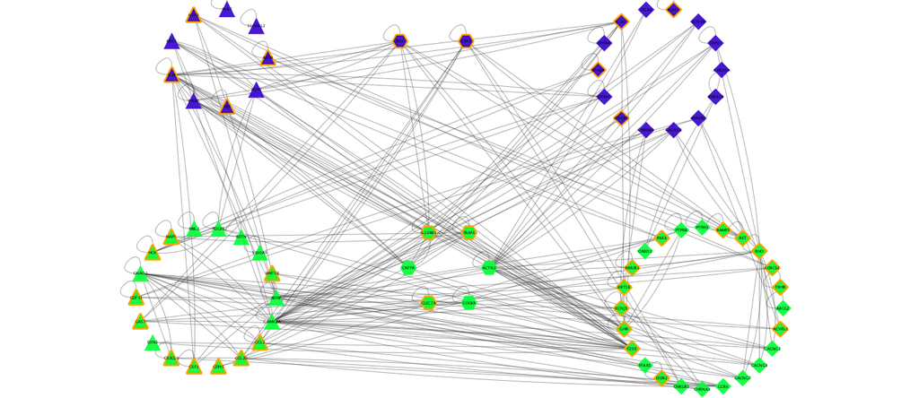

Base Receptor- Ligand interaction network

```r
output_network_file <- paste(figures_directory,"screenshot_networ.png",sep="/")

url_png <- paste(base.url,"networks",network.suid,"views/first.png", sep="/")
response <- GET(url=url_png)
writeBin(response$content, output_network_file)
```